# Boost your R-workflow with Git and GitHub

October 7, 2015. R users group of ESS

## Your experience: tracking of changes

Do you use Tracking of changes in Microsoft Word or Revision history in Google Drive?

[figure not shown]

## Your experience: collaboration

- Copies of files by email
- Shared drive (T:, Dropbox)
- Google Documents; MS Office 365

## Why version control for R users?

- Track of your work
- Separate branch for every standalone task (fix or improvement)
- Collaboration

There are many programms for version control (e.g. Subversion), but we vote for **Git**!

## Git software

Developer: Linus Torvalds (a Finnish gentleman and creator of Linux kernel)

Target: Linux kernel

Aims:

- to control files' revisions (12,020,528 lines spread over 36,595 unique files);
- to support collaboration (12,000 programmers);
- with stress on easiness of work with branches and
- absence of central server (*distributed* version control system).

Type: Free open source software

## Git

*noun* [ˈgit]

*British Slang*. A stupid or worthless person (especially a man)

## Git way of revision history

- Focus on files in simple text format
- All records in history are intentional (What + Why)
- You can work in airplane (`.git` subfolder)
- Work with branches easily

## In Word era we forgot about simple text

- Software independent
- Light (just copy & paste in Slack, email or IM)
- Friendly for human and machine
- Applications of simple text format:
  - Programming
  - Statistical analysis and data visualization
  - Documents and books (LaTeX, Markdown)
  - Flow charts (e.g. DiagrammeR R-package)
  - System settings (GNU/Linux)
  - Project management (Taskjuggler)

## GitHub

- "Web-addon" for git
- Commercial webservice with free public accounts
- "Social network" for coders
- User-friendly interface
- Easy for newbies
- Popular among R-developers

## Git clone

- In order to make a copy of an existing repo, you must clone it.
- This is not easy in RStudio directly, so you'll have to command line.
- `git clone https://github.com/octocat/Spoon-Knife.git`

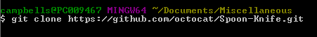

## Git add

- When files are changed, they must be added to the staging area
- This is an area to collect your files before committing

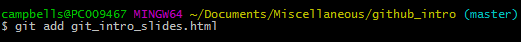

[figure not shown]

## Git commit

- Committing is like taking a snapshot. You can always go back to an old commit.
- Commits should be accompanied by an informative message

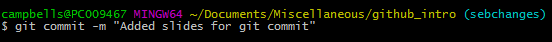

[figure not shown]

## Git push

- Code ready for the public? Time to push

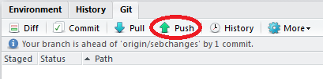

## Git pull

- Other people made changes? git pull.

## Advanced topics

- Branching
- Rebasing
- Cherry-picking
- Submodules